# Spherocylinders in HOOMD

## Overview

### Questions

- How do I run simulations of hard spherocylinders in HOOMD?

### Objectives

- Highlight the code changes needed to convert the hard sphere simulation to model hard spherocylinders.

## Spherocylinders

You can describe a spheroclyinder with a length *L* between end points and the diameter *D*. Place *N_particles* particles in the at a density of $\rho^*$. $\rho^*$ is the packing fraction relative to the densest possible packing (in the range 0-1) and is commonly used in the spheroclyinder literature.

```python
L=5
D=1
N_particles = 50
rho_star = 0.53
```

You can represent a spherocylinder as a 2-vertex spheropolyhedron.

```python
mc = hoomd.hpmc.integrate.ConvexSpheropolyhedron(seed=1)
mc.shape['spherocylinder'] = dict(vertices=[[0,0,-L/2],
                                            [0,0,L/2]],
                                  sweep_radius=D/2)
```

## Setting the initial condition

The spherical caps extend past the end points, so end-to-end spherocylinders must be placed at least a distance of L+D apart.

```python
snapshot = gsd.hoomd.Snapshot()
snapshot.particles.N = N_particles

spacing = D * 1.1
K = math.ceil(N_particles**(1/2))
box_L = K * spacing
x = numpy.linspace(-box_L / 2, box_L / 2, K, endpoint=False)
position_2d = list(itertools.product(x, repeat=2))
position_2d = position_2d[0:N_particles]
```

```python
snapshot.particles.position = numpy.zeros(shape=(N_particles, 3))
snapshot.particles.position[:,0:2] = position_2d
snapshot.particles.orientation = [1,0,0,0]*N_particles
snapshot.particles.types = ['spherocylinder']
snapshot.configuration.box = [box_L, box_L, 2.0*(box_L + D), 0, 0, 0]

with gsd.hoomd.open(name='lattice.gsd', mode='wb') as f:
    f.append(snapshot)
```

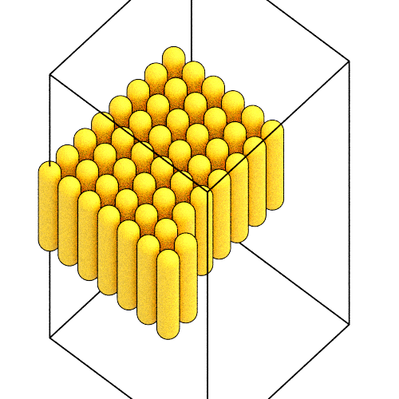

```python
render(snapshot, dict(L=L, D=D))
```

## Randomizing the system

As with the hard spheres, run the simulation to randomize the particle positions and orientations.

```python
cpu = hoomd.device.CPU()
sim = hoomd.Simulation(device=cpu)
mc = hoomd.hpmc.integrate.ConvexSpheropolyhedron(seed=1)
sim.operations.integrator = mc
mc.shape['spherocylinder'] = dict(vertices=[[0,0,-L/2],
                                            [0,0,L/2]],
                                  sweep_radius=D/2)
sim.create_state_from_gsd(filename='lattice.gsd')
sim.run(10e3)
hoomd.write.GSD.write(state=sim.state, filename='random.gsd')
```

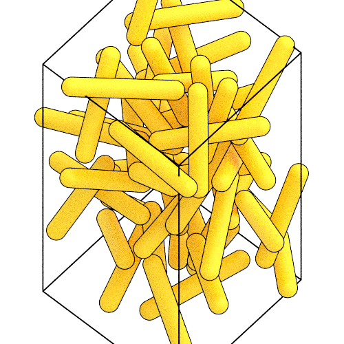

```python
render(sim.state.snapshot, dict(L=L, D=D))
```

## Compressing the system

Use **QuickCompress** to compress the simulation to the target density. Differences compared to the hard sphere compression code: Computation of the final box, **MoveSize** applies to 'a' moves as well as 'd'.

```python
rho_c = 2/(math.sqrt(2) + (L/D)*math.sqrt(3))
rho = rho_c * rho_star
box_V = sim.state.N_particles / rho
box_L=box_V**(1/3)
final_box = hoomd.Box.cube(box_L)

compress = hoomd.hpmc.update.QuickCompress(trigger=hoomd.trigger.Periodic(10), seed=1,
                                           target_box = final_box)
sim.operations.updaters.append(compress)

tune = hoomd.hpmc.tune.MoveSize.scale_solver(moves=['a', 'd'],
                                             target=0.2,
                                             trigger=hoomd.trigger.Periodic(10),
                                             max_translation_move=0.2,
                                             max_rotation_move=0.2)
sim.operations.tuners.append(tune)

while not compress.complete and sim.timestep < 5e4:
    sim.run(1000)

hoomd.write.GSD.write(state=sim.state, filename='compressed.gsd')
```

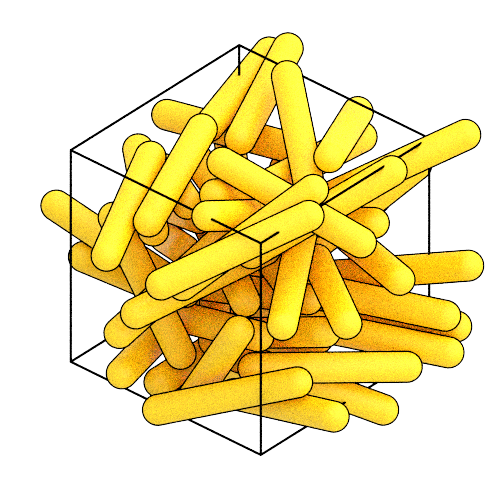

```python
render(sim.state.snapshot, dict(L=L, D=D))
```

## Equilibrating the system

Tune both 'a' and 'd' move sizes and run the simulation for 200,000 steps.

```python
gsd_writer = hoomd.write.GSD(filename='trajectory.gsd',
                             trigger=hoomd.trigger.Periodic(1000),
                             mode='wb')
sim.operations.writers.append(gsd_writer)

tune = hoomd.hpmc.tune.MoveSize.scale_solver(moves=['a', 'd'],
                                             target=0.2,
                                             trigger=hoomd.trigger.And(
                                                 [hoomd.trigger.Periodic(100),
                                                  hoomd.trigger.Before(sim.timestep + 5000)]))
sim.operations.tuners.append(tune)

logger = hoomd.logging.Logger(categories=['scalar', 'string'])
logger.add(sim, quantities=['timestep', 'final_timestep', 'tps'])
table = hoomd.write.Table(trigger=hoomd.trigger.Periodic(period=5000),
                          logger=logger)
sim.operations.writers.append(table)

sim.run(200e3)
```

```
Simulation.timestep Simulation.final_timestep  Simulation.tps
       15000                 213000              642.64584
       20000                 213000              645.45568
       25000                 213000              651.42693
       30000                 213000              645.15994
       35000                 213000              636.58896
       40000                 213000              632.89654
       45000                 213000              630.44532
       50000                 213000              628.01177
       55000                 213000              627.36077
       60000                 213000              624.99021
       65000                 213000              622.93607
       70000                 213000              619.80328
       75000                 213000              614.74483
       80000                 213000              610.42855
```

[output cut: 26 more lines]

## Analyze the results

Visualize the final state of the simulation.

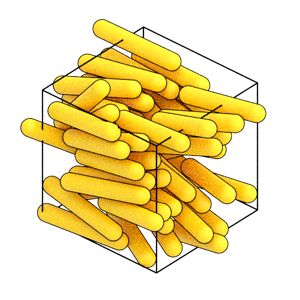

```python
render(sim.state.snapshot, dict(L=L, D=D))
```

Compute the nematic order in each frame of the trajectory.

```python
with gsd.hoomd.open('trajectory.gsd') as traj:
    nematic = freud.order.Nematic([0, 0, 1])
    nematic_order = []
    for frame in traj:
        nematic.compute(frame.particles.orientation)
        nematic_order.append(nematic.order)

fig = matplotlib.figure.Figure(figsize=(10, 6.18))
ax = fig.add_subplot()
ax.plot(nematic_order)
ax.set_xlabel('frame')
ax.set_ylabel('average nematic order parameter')
ax.set_ylim([0, 1]);
```

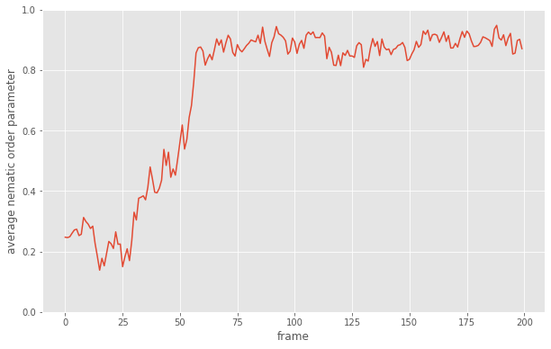

```python
fig
```